# Decision Trees

# Exercise 1 - Explore the Hiters data

```r
library(tree)
library(ISLR)
library(ggplot2)
```

get rid of old stuff

```r
rm(list = ls())
par(mfrow = c(1,1)) # set plotting window to default
```

# Regression trees

```r
data("Hitters") # In the tree package
?Hitters
head(Hitters)
```

|  | AtBat | Hits | HmRun | Runs | RBI | Walks | Years | CAtBat | CHits | CHmRun | CRuns | CRBI | CWalks | League | Division | PutOuts | Assists | Errors | Salary | NewLeague |
| --- | --- | --- | --- | --- | --- | --- | --- | --- | --- | --- | --- | --- | --- | --- | --- | --- | --- | --- | --- | --- |
| -Andy Allanson | 293 | 66 | 1 | 30 | 29 | 14 | 1 | 293 | 66 | 1 | 30 | 29 | 14 | A | E | 446 | 33 | 20 | NA | A |
| -Alan Ashby | 315 | 81 | 7 | 24 | 38 | 39 | 14 | 3449 | 835 | 69 | 321 | 414 | 375 | N | W | 632 | 43 | 10 | 475.0 | N |
| -Alvin Davis | 479 | 130 | 18 | 66 | 72 | 76 | 3 | 1624 | 457 | 63 | 224 | 266 | 263 | A | W | 880 | 82 | 14 | 480.0 | A |
| -Andre Dawson | 496 | 141 | 20 | 65 | 78 | 37 | 11 | 5628 | 1575 | 225 | 828 | 838 | 354 | N | E | 200 | 11 | 3 | 500.0 | N |
| -Andres Galarraga | 321 | 87 | 10 | 39 | 42 | 30 | 2 | 396 | 101 | 12 | 48 | 46 | 33 | N | E | 805 | 40 | 4 | 91.5 | N |
| -Alfredo Griffin | 594 | 169 | 4 | 74 | 51 | 35 | 11 | 4408 | 1133 | 19 | 501 | 336 | 194 | A | W | 282 | 421 | 25 | 750.0 | A |

Remove incomplete observations

```r
sum(is.na(Hitters))
```

```
[1] 59
```

```r
Hitters <- na.omit(Hitters)
```

Salary is our target variable We log-transfoorm it so that its distribution has more of a typical bell-shape. We need to remember later on that Salary is logarithmized!

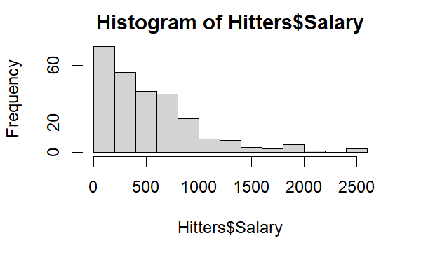

```r
hist(Hitters$Salary)
```

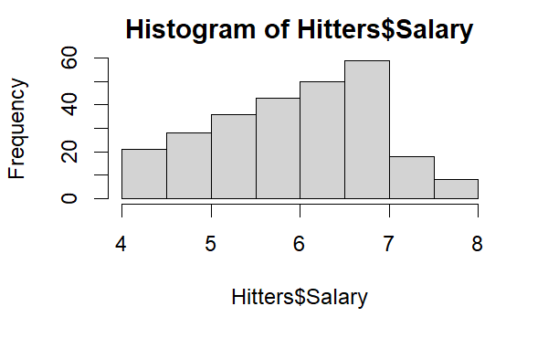

```r
Hitters$Salary <- log(Hitters$Salary)
hist(Hitters$Salary)
```

```r
attach(Hitters)
```

# Exercise 2 - Fit a regression tree on the Hitters data (2 input variables)

Sample 70% of the row indices for subsetting as training data.

```r
set.seed(1)
trainHit <- sample(1:nrow(Hitters), 0.7*nrow(Hitters))
Hitters.train <- Hitters[trainHit,]
Hitters.test <- Hitters[-trainHit,]
```

Fir a regression tree to predict Salary from Years and Hits

```r
tree.salaryHitters <- tree(Salary ~ Years + Hits, data = Hitters)
```

tree() uses binary recursive partitioning. The split which maximizes the reduction in impurity is chosen. The data set is then split and the process is repeated. Splitting continues until the terminal nodes are too small or too few to be split. Tree growth is limited to a depth of 31 by the use of integers to label nodes.

```r
summary(tree.salaryHitters)
```

```
Regression tree:
tree(formula = Salary ~ Years + Hits, data = Hitters)
Number of terminal nodes:  8
Residual mean deviance:  0.2708 = 69.06 / 255
Distribution of residuals:
   Min. 1st Qu.  Median    Mean 3rd Qu.    Max.
-2.2400 -0.2980 -0.0365  0.0000  0.3233  2.1520
```

Output: - There are 8 terminal nodes (“leaves”) of the tree. - Here “residual mean deviance” is just mean squared error (RMS)

Plot the regression tree

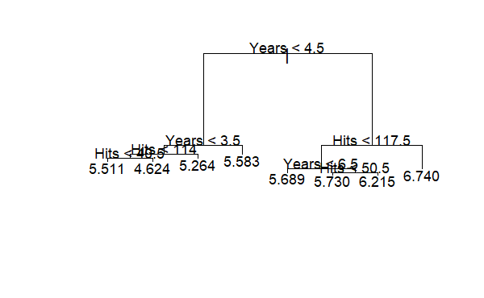

```r
plot(tree.salaryHitters)
text(tree.salaryHitters, cex = 0.75) # cex sets the character size
```

Plot the corresponding regions.

simple plot

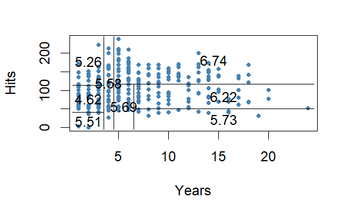

```r
plot(Hitters$Years, Hitters$Hits, col = 'steelblue', pch = 20, xlab = "Years", ylab = "Hits")
partition.tree(tree.salaryHitters, ordvars = c("Years", "Hits"), add = TRUE, cex = 1)
```

Plot with salary value in color code Prepare Salary data for plot

```r
salary.deciles = quantile(Salary, 0:10/10)
cut.salary = cut(Hitters$Salary, salary.deciles, include.lowest = TRUE)
```

Plot the point cloud and regions

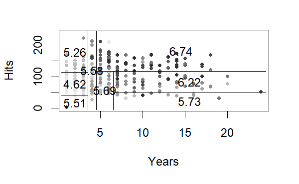

```r
plot(Years, Hits, col = grey(10:2/11)[cut.salary], pch = 20, xlab = "Years", ylab = "Hits")
partition.tree(tree.salaryHitters, ordvars = c("Years", "Hits"), add = TRUE, cex = 1)
```

```r
tree.salaryHitters
```

```
node), split, n, deviance, yval
      * denotes terminal node

 1) root 263 207.200 5.927
   2) Years < 4.5 90  42.350 5.107
     4) Years < 3.5 62  23.010 4.892
       8) Hits < 114 43  17.150 4.727
        16) Hits < 40.5 5  10.400 5.511 *
        17) Hits > 40.5 38   3.280 4.624 *
       9) Hits > 114 19   2.069 5.264 *
     5) Years > 3.5 28  10.130 5.583 *
   3) Years > 4.5 173  72.710 6.354
     6) Hits < 117.5 90  28.090 5.998
      12) Years < 6.5 26   7.238 5.689 *
      13) Years > 6.5 64  17.350 6.124
        26) Hits < 50.5 12   2.689 5.730 *
        27) Hits > 50.5 52  12.370 6.215 *
     7) Hits > 117.5 83  20.880 6.740 *
```

```r
tree.salaryHitters
```

## Fit a regression tree on the Hitters data (all input variables)

```r
tree.salaryHitters <- tree(Salary ~ .-Salary, data = Hitters)
summary(tree.salaryHitters)
```

```
Regression tree:
tree(formula = Salary ~ . - Salary, data = Hitters)
Variables actually used in tree construction:
[1] "CAtBat" "CHits"  "AtBat"  "CRuns"  "Hits"   "Walks"
[7] "CRBI"
Number of terminal nodes:  9
Residual mean deviance:  0.1694 = 43.03 / 254
Distribution of residuals:
   Min. 1st Qu.  Median    Mean 3rd Qu.    Max.
-1.7080 -0.2213  0.0353  0.0000  0.2303  1.7020
```

Plot the regression tree

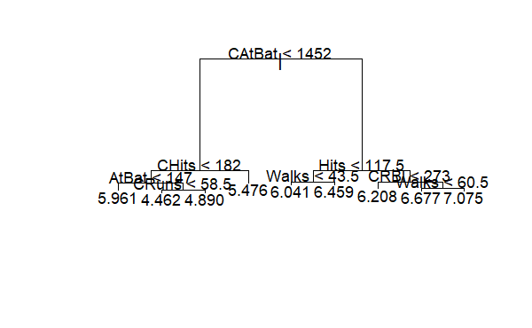

```r
plot(tree.salaryHitters)
text(tree.salaryHitters, cex = 0.75)
```

Use the tree to make predictions on the test set

```r
tree.salaryHitters.pred <- predict(tree.salaryHitters, newdata = Hitters.test)
```

Compare predictions of the regression tree with true values (visually) We plot the predictions against ground truth. A perfect prediction would give a line with intercept 0 and slope 1

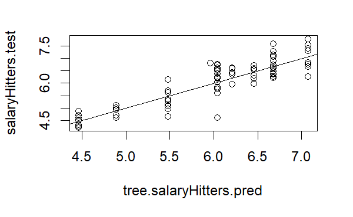

```r
salaryHitters.test <- Hitters.test$Salary
plot(tree.salaryHitters.pred,salaryHitters.test)
abline (0,1)
```

Calculate the mean squared error on test data

```r
salaryHitters.test <- Hitters[-trainHit ,"Salary"]
(tree.salaryHitters.MSE <- mean((tree.salaryHitters.pred - salaryHitters.test)^2))
```

```
[1] 0.1891052
```

```r
sqrt(tree.salaryHitters.MSE)
```

```
[1] 0.4348623
```

# Exercise 3 - Pruning the regression tree (Hitters data)

Cost-Complexity Pruning Goal: prune the trees to avoid high variance and overfitting. Positive effects: - smaller *test” errors (due to less overfitting) - higher interpretability (due to smaller trees)

Use cross-validation to find the optimal parameter / alpha for cost-complexity pruning

```r
set.seed(3)
?cv.tree
cv.Hitters = cv.tree(tree.salaryHitters)
```

Runs a K-fold cross validation experiment to find the number of misclassifications as a function of the cost-complexity parameter /alpha

```r
cv.Hitters
```

```
$size
[1] 9 8 7 6 5 4 3 2 1

$dev
[1]  69.02298  71.47475  72.15869  69.30675  72.69363  79.26205
[7]  98.98813  98.03481 209.89294

$k
[1]       -Inf   2.314754   2.423858   2.713047   6.377474
[6]   7.769090  11.970263  12.695982 117.857612

$method
[1] "deviance"

attr(,"class")
[1] "prune"         "tree.sequence"
```

$k: cost-complexity parameter (corresponds to /alpha) Notice that /alpha is increasing (corresponding tot he pruning sequence) $size: number of terminal nodes of each tree Notice that the size is decreasing (corresponding to the pruning sequence) $dev: *cross validation* error rate The full tree (with size 9, i.e. 9 terminal nodes) has the lowest cross-validation error

Plot the cross-validation error-rate as a function of both size and /alpha (k):

```r
par(mfrow=c(1,2))
plot(cv.Hitters$size, cv.Hitters$dev, type = "b") # type = "b= means plot both, points and lines
plot(cv.Hitters$k, cv.Hitters$dev, type = "b")
```

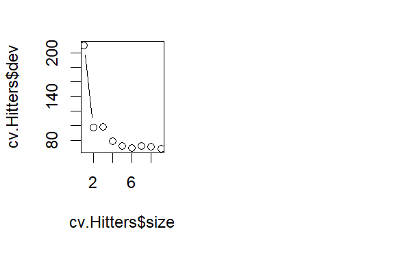

```r
par(mfrow=c(1,1))
```

We do not need to prune the tree, since the full tree has minimal cross-validation error Yet, to show how to prune, here is the code

```r
prune.salaryHitters <- prune.tree(tree.salaryHitters, best = 6)
```

prune.tree determines the nested cost-complexity sequence best = 6 gets the 6-node tree in the cost-complexity sequence

Plot the pruned regression tree

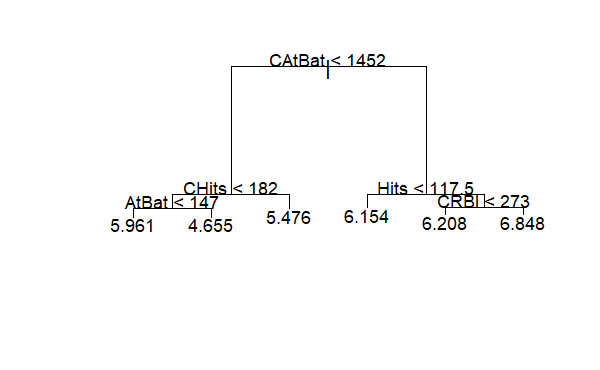

```r
plot(prune.salaryHitters)
text(prune.salaryHitters, cex = 0.75)
```

# Exercise 4 - Fitting and pruning a classification tree (Heart data)

Classification trees

load and inspect the Heart data set This data contains a binary outcome HD for 303 patients who presented with chest pain. An outcome value of Yes indicates the presence of heart disease based on an angiographic test, while No means no heart disears. There are 13 predictors including Age, Sex, Chol (a cholestorol measurement) and other heart and lung function measurements

```r
Heart <- read.csv("./Heart.csv")
attach(Heart)
head(Heart)
```

|  | X | Age | Sex | ChestPain | RestBP | Chol | Fbs | RestECG | MaxHR | ExAng | Oldpeak | Slope | Ca | Thal | AHD |
| --- | --- | --- | --- | --- | --- | --- | --- | --- | --- | --- | --- | --- | --- | --- | --- |
| 1 | 1 | 63 | 1 | typical | 145 | 233 | 1 | 2 | 150 | 0 | 2.3 | 3 | 0 | fixed | No |
| 2 | 2 | 67 | 1 | asymptomatic | 160 | 286 | 0 | 2 | 108 | 1 | 1.5 | 2 | 3 | normal | Yes |
| 3 | 3 | 67 | 1 | asymptomatic | 120 | 229 | 0 | 2 | 129 | 1 | 2.6 | 2 | 2 | reversable | Yes |
| 4 | 4 | 37 | 1 | nonanginal | 130 | 250 | 0 | 0 | 187 | 0 | 3.5 | 3 | 0 | normal | No |
| 5 | 5 | 41 | 0 | nontypical | 130 | 204 | 0 | 2 | 172 | 0 | 1.4 | 1 | 0 | normal | No |
| 6 | 6 | 56 | 1 | nontypical | 120 | 236 | 0 | 0 | 178 | 0 | 0.8 | 1 | 0 | normal | No |

```r
Heart <- Heart [,-1] # Remove the row identifier (we don't use it as a predictor)
```

The categorical varaibles need to be of type factor rather than character to work with tree()

```r
str(Heart)
```

```
'data.frame':   303 obs. of  14 variables:
 $ Age      : int  63 67 67 37 41 56 62 57 63 53 ...
 $ Sex      : int  1 1 1 1 0 1 0 0 1 1 ...
 $ ChestPain: chr  "typical" "asymptomatic" "asymptomatic" "nonanginal" ...
 $ RestBP   : int  145 160 120 130 130 120 140 120 130 140 ...
 $ Chol     : int  233 286 229 250 204 236 268 354 254 203 ...
 $ Fbs      : int  1 0 0 0 0 0 0 0 0 1 ...
 $ RestECG  : int  2 2 2 0 2 0 2 0 2 2 ...
 $ MaxHR    : int  150 108 129 187 172 178 160 163 147 155 ...
 $ ExAng    : int  0 1 1 0 0 0 0 1 0 1 ...
 $ Oldpeak  : num  2.3 1.5 2.6 3.5 1.4 0.8 3.6 0.6 1.4 3.1 ...
 $ Slope    : int  3 2 2 3 1 1 3 1 2 3 ...
 $ Ca       : int  0 3 2 0 0 0 2 0 1 0 ...
 $ Thal     : chr  "fixed" "normal" "reversable" "normal" ...
 $ AHD      : chr  "No" "Yes" "Yes" "No" ...
```

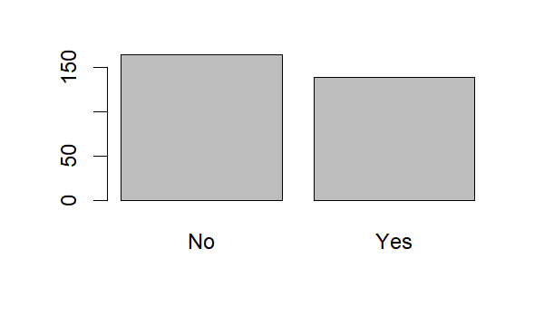

```r
Heart$AHD = as.factor(Heart$AHD)
Heart$ChestPain = as.factor(Heart$ChestPain)
Heart$Thal = as.factor(Heart$Thal)
plot(Heart$AHD)
```

Sample 70% of the row indixes for subsetting as training data

```r
set.seed(2)
trainHeart <- sample(1:nrow(Heart), 0.7*nrow(Heart))
Heart.train <- Heart[trainHeart,]
Heart.test <- Heart[-trainHeart,]
```

Train classification tree on training data

```r
tree.AHDHeart <- tree(AHD ~ .-AHD, data =Heart.train)
```

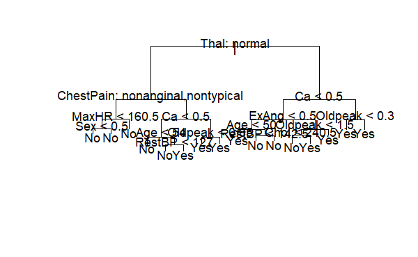

```r
plot(tree.AHDHeart)
text(tree.AHDHeart, cex = 0.75, pretty = 0)
```

```r
summary(tree.AHDHeart)
```

```
Classification tree:
tree(formula = AHD ~ . - AHD, data = Heart.train)
Variables actually used in tree construction:
 [1] "Thal"      "ChestPain" "MaxHR"     "Sex"       "Ca"        "Age"       "RestBP"
 [8] "Oldpeak"   "ExAng"     "Chol"
Number of terminal nodes:  16
Residual mean deviance:  0.4401 = 84.93 / 193
Misclassification error rate: 0.1053 = 22 / 209
```

```r
tree.AHDHeart
```

```
node), split, n, deviance, yval, (yprob)
      * denotes terminal node

 1) root 209 289.500 No ( 0.51675 0.48325 )
   2) Thal: normal 113 126.500 No ( 0.75221 0.24779 )
     4) ChestPain: nonanginal,nontypical 66  40.210 No ( 0.90909 0.09091 )
       8) MaxHR < 160.5 29  29.570 No ( 0.79310 0.20690 )
        16) Sex < 0.5 16   7.481 No ( 0.93750 0.06250 ) *
        17) Sex > 0.5 13  17.320 No ( 0.61538 0.38462 ) *
       9) MaxHR > 160.5 37   0.000 No ( 1.00000 0.00000 ) *
     5) ChestPain: asymptomatic,typical 47  64.960 No ( 0.53191 0.46809 )
      10) Ca < 0.5 26  25.460 No ( 0.80769 0.19231 )
        20) Age < 54 13   0.000 No ( 1.00000 0.00000 ) *
        21) Age > 54 13  17.320 No ( 0.61538 0.38462 )
          42) RestBP < 127 5   0.000 No ( 1.00000 0.00000 ) *
          43) RestBP > 127 8  10.590 Yes ( 0.37500 0.62500 ) *
      11) Ca > 0.5 21  20.450 Yes ( 0.19048 0.80952 )
        22) Oldpeak < 0.85 10  13.460 Yes ( 0.40000 0.60000 ) *
        23) Oldpeak > 0.85 11   0.000 Yes ( 0.00000 1.00000 ) *
   3) Thal: fixed,reversable 96 105.700 Yes ( 0.23958 0.76042 )
     6) Ca < 0.5 44  60.630 Yes ( 0.45455 0.54545 )
      12) ExAng < 0.5 24  30.550 No ( 0.66667 0.33333 )
        24) Age < 50 9  11.460 Yes ( 0.33333 0.66667 ) *
        25) Age > 50 15  11.780 No ( 0.86667 0.13333 )
          50) RestBP < 142.5 10   0.000 No ( 1.00000 0.00000 ) *
          51) RestBP > 142.5 5   6.730 No ( 0.60000 0.40000 ) *
      13) ExAng > 0.5 20  20.020 Yes ( 0.20000 0.80000 )
        26) Oldpeak < 1.5 10  13.460 Yes ( 0.40000 0.60000 )
          52) Chol < 240.5 5   5.004 No ( 0.80000 0.20000 ) *
          53) Chol > 240.5 5   0.000 Yes ( 0.00000 1.00000 ) *
        27) Oldpeak > 1.5 10   0.000 Yes ( 0.00000 1.00000 ) *
     7) Ca > 0.5 52  22.940 Yes ( 0.05769 0.94231 )
      14) Oldpeak < 0.3 11  12.890 Yes ( 0.27273 0.72727 ) *
      15) Oldpeak > 0.3 41   0.000 Yes ( 0.00000 1.00000 ) *
```

node): node number split: split criterion e.g., Thal: normal or Ca < 0.5 n: number of observations in that branch deviance (the smaller the better) yval: overall prediction for the branch (Yes or No) (ybrob): the fraction of observations in that branch that take on the values (Yes No) * denotes terminal node

use classification trees to predict *test data*

```r
tree.AHDHeart.pred <- predict(tree.AHDHeart, Heart.test, type = "class")
```

Confusion table to determine classification error on test data

```r
(tree.AHDHeart.pred.ct <- table(tree.AHDHeart.pred, Heart.test$AHD))
```

```
tree.AHDHeart.pred No Yes
               No  39   8
               Yes 14  30
```

```r
(tree.AHDHeart.pred.correct <- (tree.AHDHeart.pred.ct[1,1] + tree.AHDHeart.pred.ct[2,2]) / sum(tree.AHDHeart.pred.ct)) # portion incorrectly classified
```

```
[1] 0.7582418
```

```r
(tree.AHD.testError <- 1 - tree.AHDHeart.pred.correct) # test error
```

```
[1] 0.2417582
```

## Cost-complexity pruning

Goal: prune trees to avoid high variance and overfitting Positive effects: - smaller *test* errors (due to less overfitting) - higher interpretability (due to smaller trees)

use cross-validation to find the optimal parameter alpha for cost-complexity pruning

```r
set.seed(3)
cv.Heart = cv.tree(tree.AHDHeart, FUN = prune.misclass)
```

Runs a k-fold cross validation experiment to find the number of misclassifications as a function of the cost-complexity parameter alpha. “Fun = prune.misclass”: The *classification error rate* should guide the cross-validation and pruning process (as opposed to Gini index or entropy) If FUN is not specified, deviance is used as default (which is a version of entropy) –> Remember: If prediction accuracy is the goal, the error rate is preferable for pruning.

```r
cv.Heart
```

```
$size
[1] 16 11  9  7  6  4  2  1

$dev
[1]  49  51  52  50  52  56  68 103

$k
[1] -Inf  0.0  1.0  1.5  3.0  4.0  6.5 50.0

$method
[1] "misclass"

attr(,"class")
[1] "prune"         "tree.sequence"
```

plot the cross-validation error-rate as a function of both size and alpha

```r
par(mfrow=c(1,2))
plot(cv.Heart$size, cv.Heart$dev, type = "b")
plot(cv.Heart$k, cv.Heart$dev, type = "b")
```

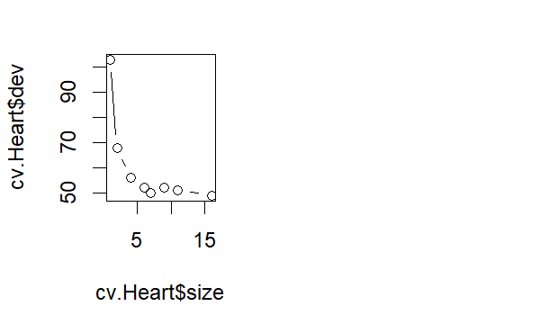

```r
par(mfrow=c(1,1))
```

do the actual pruning

```r
prune.AHDHeart <- prune.misclass(tree.AHDHeart, best = 7)
```

prune.misclass: is an abbreviation for prune.tree(method = “misclass”) for use with cv.tree Here, prune.tree determines the nested cost-complexity sequence best = 7: get hte 7 node tree in the cost-complexity sequence

plot the pruned tree

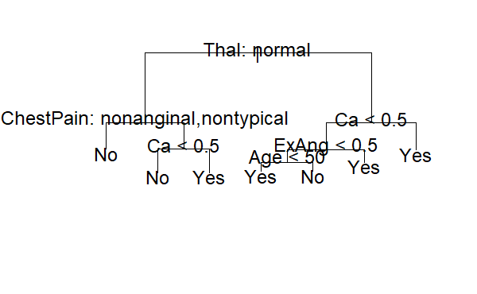

```r
plot(prune.AHDHeart)
text(prune.AHDHeart, pretty = 0)
```

use the pruned tree to predict test data

```r
prune.AHDHeart.pred <- predict(prune.AHDHeart, Heart.test, type = "class")
```

confusion table to determine classification error on test data

```r
(prune.AHDHeart.pred.ct <- table(prune.AHDHeart.pred, Heart.test$AHD))
```

```
prune.AHDHeart.pred No Yes
                No  44   9
                Yes  9  29
```

```r
(prune.AHDHeart.correct <- (prune.AHDHeart.pred.ct[1,1] + prune.AHDHeart.pred.ct[2,2]) / sum(prune.AHDHeart.pred.ct))
```

```
[1] 0.8021978
```

```r
(prune.AHDHeart.testError <- 1 - prune.AHDHeart.correct)
```

```
[1] 0.1978022
```

Compare with test error of unpruned tree

```r
tree.AHD.testError
```

```
[1] 0.2417582
```

Smaller error with pruning!